# T-tests: one-sample, two-sample, and paired tests

XDASI Fall 2021

10/25/2021

## Review

- Random samples
- Standard normal distribution
  - What is a $z$-score?
  - What are the quantiles?
  - How do you capture height vs. area?
- Sampling distribution of the sample mean
- Standard error
- Confidence intervals
- What is a $z$-score?
- $t$-statistics vs. $z$-statistics : when is each appropriate?
- P values : one- vs. two-sided
- What does qt(0.975) represent?

This worksheet illustrates basic concepts and practical application of significance tests for different experimental scenarios.

## Sample data

To illustrate the various types of $t$-test, we will use a simple case study where a drug was administered to 10 random patients (or test subjects) and its effect was compared to that of a placebo pill. Three different experimental designs are illustrated:

- Treatment sample vs. control population (one-sample test)
- Two random samples: treatment vs. control (two-sample test)
- One sample measured before and after treatment (paired test)

In all three scenarios, measurements were collected to answer the question:

*Is there a significant difference between the control subjects and the those who were given the drug?*

To generate sample data for this exercise, I simulated some normally distributed data for a large control population and wrote this to a file (`placebo_pop.csv`). I then drew two random samples from normal distributions with different means.

```r
# population data
# simulate 1000 samples from a normal with the same parameters
Placebo_pop = rnorm(1000, mean = 50.482, sd = 2.693)
head(Placebo_pop)
```

```
## [1] 53.22757 43.58040 50.14578 52.88038 52.87473 47.45281
```

```r
# write to file
# Placebo_pop = data.frame(value = Placebo_pop)
# write.table(Placebo_pop, file = "placebo_pop.csv", row.names = FALSE, col.names = FALSE)

# load from file
# Placebo_pop = read.table("placebo_pop2.csv", header=FALSE)
# Placebo_pop = Placebo_pop[,1]  # turns data frame into a simple vector
# head(Placebo_pop)

# sample data
Placebo = c(54,51,58,44,55,52,42,47,58,46)
Drug = c(54,73,53,70,73,68,52,65,65,60)
```

## Sample vs. population parameters

Compare the mean and SD of the Placebo population and the Placebo sample. Do these look pretty different? Why?

```r
## check the parameters from the true population
paste("Pop. mean = ",round(mean(Placebo_pop),3),
      " ; Pop. SD = ",round(sd(Placebo_pop),4))
```

```
## [1] "Pop. mean =  50.431  ; Pop. SD =  2.7191"
```

```r
## check the parameters from the estimated population
paste("Sample mean = ",round(mean(Placebo),3),
      " ; Sample SD = ",round(sd(Placebo),4))
```

```
## [1] "Sample mean =  50.7  ; Sample SD =  5.7164"
```

```r
paste("Drug sample = ",round(mean(Drug),3),
      "; Drug sample = ",round(sd(Drug),4))
```

```
## [1] "Drug sample =  63.3 ; Drug sample =  8.111"
```

## Placebo population distribution

Let’s take a look at the “population” and see where the two samples means fall relative to the control distribution.

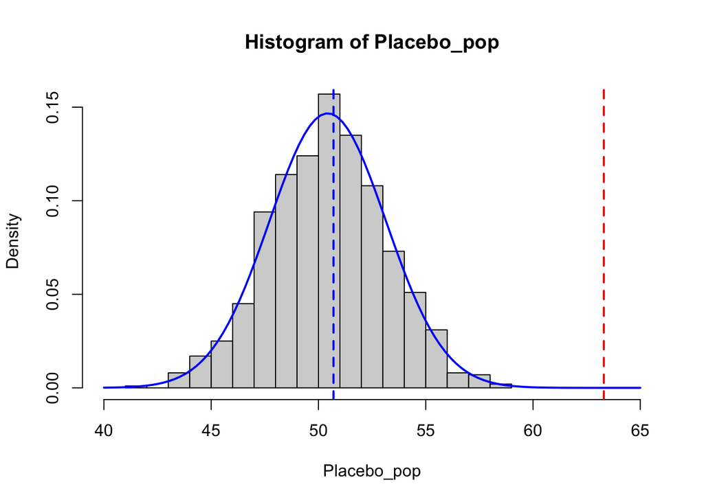

```r
## visualize the distribution and sample means
hist(Placebo_pop, breaks=20, freq=FALSE, xlim=c(40,65))
xfit = seq(40,65,length=100)
yfit = dnorm(xfit,mean=mean(Placebo_pop),sd=sd(Placebo_pop))
lines(xfit,yfit,col="blue",lwd = 2)
abline(v = mean(Placebo), col="blue", lwd=2, lty=2)
abline(v = mean(Drug), col="red", lwd=2, lty=2)  # off scale
```

## t-distrubution

### Confidence Intervals

The standard error is very helpful because it gives us an idea of how close our data are to the actual mean. We can use the SE to help define **Confidence Intervals (CI)** for the the actual population means from which the samples were drawn.

Here, we assume that we have random samples and that the measurements are normally distributed in the population. The estimated distribution of the sample means will then follow a $t$-distribution, which is similar to a standard normal distribution but with heavier tails. As the sample size increases, the tails of the $t$-distribution become smaller and it resembles closely the $Z$-distribution.

Let’s calculate the 95% CI for the mean of each population that the samples are drawn from. Here are the steps we need:

1. Use the `qt()` *quantile function* to identify the critical $t$-score, $t_{crit}$, for the the 95% CI with the appropriate $df$.
2. Estimate the mean and SEM for the Placebo and Drug samples.
3. Use these values to compute the 95% CI’s for the two samples.

```r
## t_critical: t-score for 97.5% area (range is from 2.5% to 97.5%)
## also need degrees of freedom for this distribution (length - 1)
##   df = same for Placebo and Drug (9)

# Placebo and Drug are the same length so this works for both df
t_0.975 = qt(p = 0.975, df = length(Placebo)-1)  # t-score for 97.5th percentile
paste0("t_crit = ",round(t_0.975,4))
```

```
## [1] "t_crit = 2.2622"
```

```r
# note this is bigger than the corresponding z-score would be
# n_0.975 = qnorm(p = 0.975)
# n_0.975


# placebo SEM
Pmean = mean(Placebo)
Pse=sd(Placebo)/sqrt(length(Placebo))
Pmean
```

```
## [1] 50.7
```

```r
Pse
```

```
## [1] 1.8077
```

```r
# drug SEM
Dmean = mean(Drug)
Dse=sd(Drug)/sqrt(length(Drug))
Dmean
```

```
## [1] 63.3
```

```r
Dse
```

```
## [1] 2.564934
```

```r
# placebo and drug 95% CI
c(Pmean - Pse * t_0.975, Pmean + Pse * t_0.975)
```

```
## [1] 46.6107 54.7893
```

```r
c(Dmean - Dse * t_0.975, Dmean + Dse * t_0.975)
```

```
## [1] 57.49772 69.10228
```

### One-sample $t$-test

A one-sample $t$-test compares a sample against expected parameters for a larger population.

The `t.test()` function in R takes a vector of input data (a sample) and automatically finds the degrees of freedom for the corresponding $t$-distribution based on the length of the vector.

Run a one-sample $t$-test for each sample against Placebo_pop. Do the samples look like they both came from the same parent population?

```r
# Placebo sample
t.test(Placebo, mu=mean(Placebo_pop))
```

```
##
##  One Sample t-test
##
## data:  Placebo
## t = 0.14895, df = 9, p-value = 0.8849
## alternative hypothesis: true mean is not equal to 50.43074
## 95 percent confidence interval:
##  46.6107 54.7893
## sample estimates:
## mean of x
##      50.7
```

```r
# Drug sample
t.test(Drug, mu=mean(Placebo_pop))
```

```
##
##  One Sample t-test
##
## data:  Drug
## t = 5.0174, df = 9, p-value = 0.0007217
## alternative hypothesis: true mean is not equal to 50.43074
## 95 percent confidence interval:
##  57.49772 69.10228
## sample estimates:
## mean of x
##      63.3
```

You can inspect the `t.test` object using `str()`; it’s a list containing a bunch of information about the results of the $t$-test.

Do this for both the Drug and the Placebo samples. Are these the same as what you calculated above?

```r
# confidence intervals and p-values from t-tests
#str(Pt.test)

t.test(Placebo, mu=mean(Placebo_pop))$conf.int[1:2] # lower and upper CI limits
```

```
## [1] 46.6107 54.7893
```

```r
#t.test(Placebo, mu=mean(Placebo_pop))$conf.int      # also indicates 0.95 is the range

t.test(Drug, mu=mean(Placebo_pop))$conf.int[1:2]
```

```
## [1] 57.49772 69.10228
```

```r
t.test(Placebo, mu=mean(Placebo_pop))$p.value
```

```
## [1] 0.8848758
```

```r
t.test(Drug, mu=mean(Placebo_pop))$p.value
```

```
## [1] 0.0007216569
```

## Two-sample $t$-test

The **null hypothesis** is that the samples come from the same population, so their means should be the same.

$$H_o : \mu_{Drug} = \mu_{Placebo}$$
$$H_A : \mu_{Drug} \ne \mu_{Placebo}$$

### Stripchart

First let’s inspect the two samples by making two strip charts showing the mean and SEM, or the mean and 95%CI, for the Placebo and Drug samples. Refer to this helpful tutorial on adding different kinds of summary statistics to ggplot strip charts: https://ggplot2tutor.com/tutorials/summary_statistics

```r
# make a data frame
drug.placebo = data.frame(Treatment = rep(c("Placebo","Drug"),each=10), # experiment with params
                          Value = c(Placebo, Drug))
# reset levels (alphabetical by default)
drug.placebo$Treatment = factor(drug.placebo$Treatment, levels = c("Placebo","Drug"))
drug.placebo
```

```
##    Treatment Value
## 1    Placebo    54
## 2    Placebo    51
## 3    Placebo    58
## 4    Placebo    44
## 5    Placebo    55
## 6    Placebo    52
## 7    Placebo    42
## 8    Placebo    47
## 9    Placebo    58
## 10   Placebo    46
## 11      Drug    54
## 12      Drug    73
## 13      Drug    53
## 14      Drug    70
## 15      Drug    73
## 16      Drug    68
## 17      Drug    52
## 18      Drug    65
## 19      Drug    65
## 20      Drug    60
```

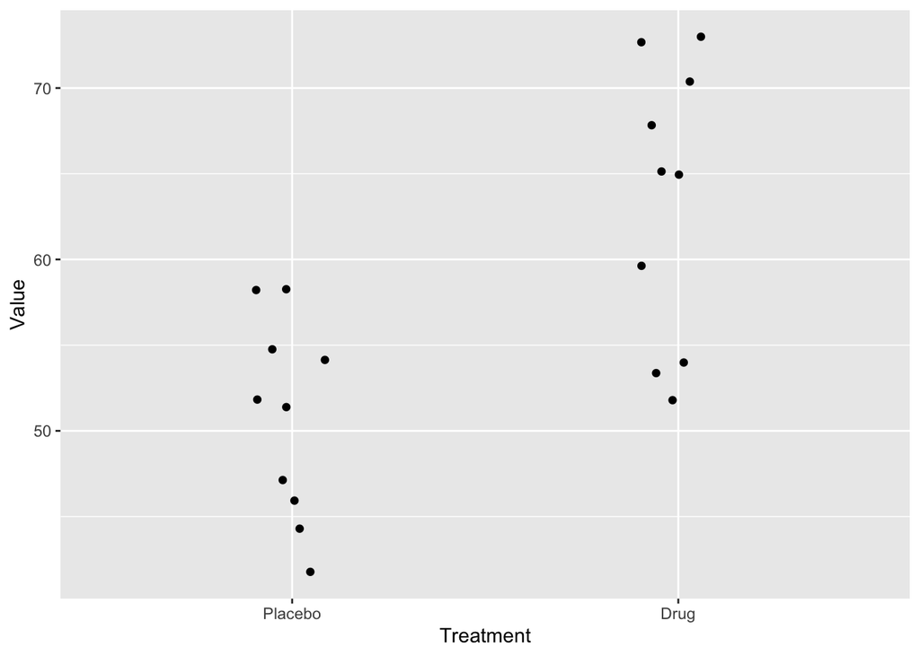

```r
# basic jitter plot
p = ggplot(drug.placebo, aes(x=Treatment, y=Value)) +
  geom_jitter(position=position_jitter(0.1))
p
```

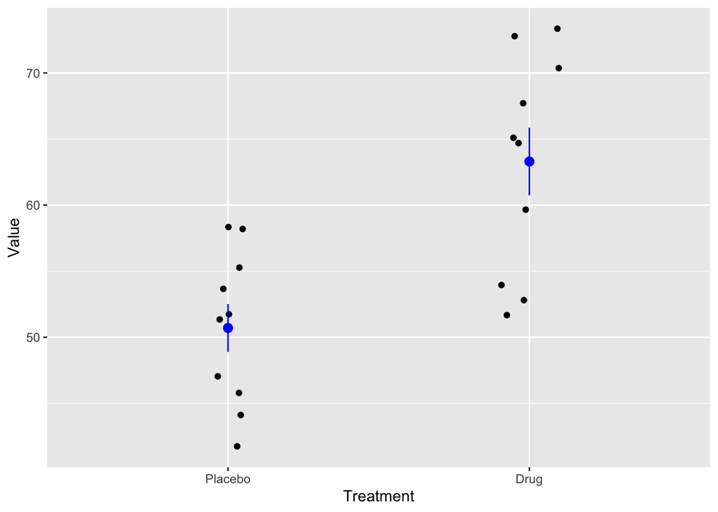

```r
# jitter plot with stats
# error bars, minmax
# p + stat_summary(geom = "errorbar",
#                  width = .1,
#                  fun.min = min,
#                  fun.max = max)

# Std error by hand (not sure if there is a function for this)
p +  stat_summary(fun = mean,
               geom = "pointrange",
               fun.max = function(x) mean(x) + sd(x) / sqrt(length(x)),
               fun.min = function(x) mean(x) - sd(x) / sqrt(length(x)),
               color="blue")
```

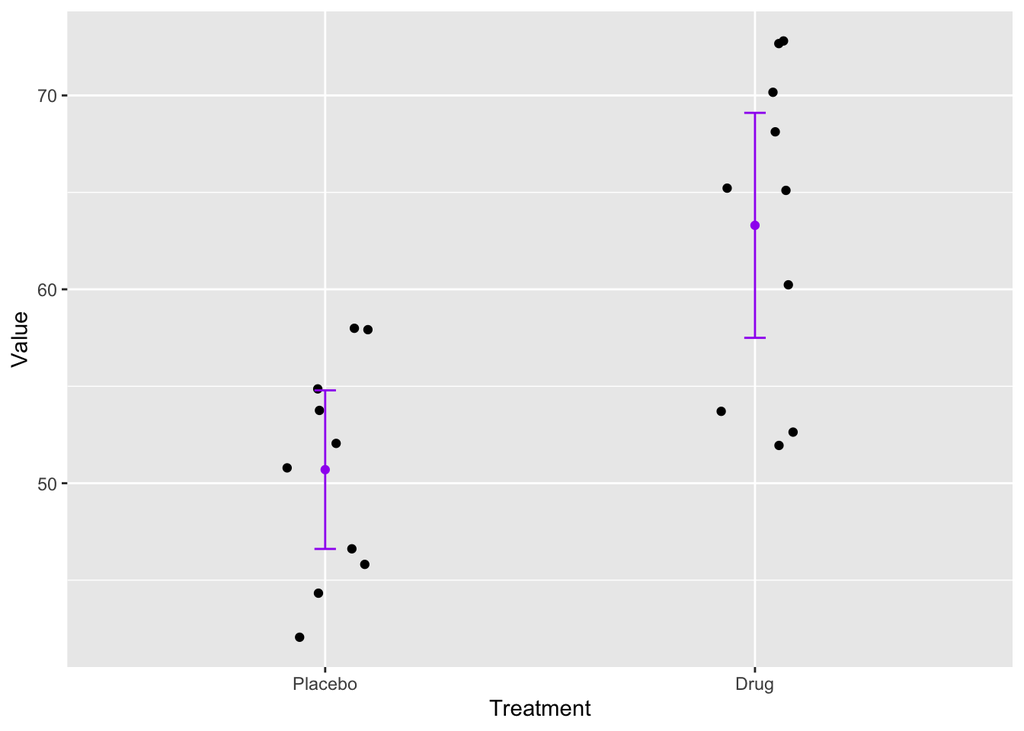

```r
# 95%CI with error bars
p +  stat_summary(fun.data = "mean_cl_normal",
               geom = "errorbar",
               width = .05, col="purple") +
  stat_summary(fun = "mean", geom = "point", col="purple")
```

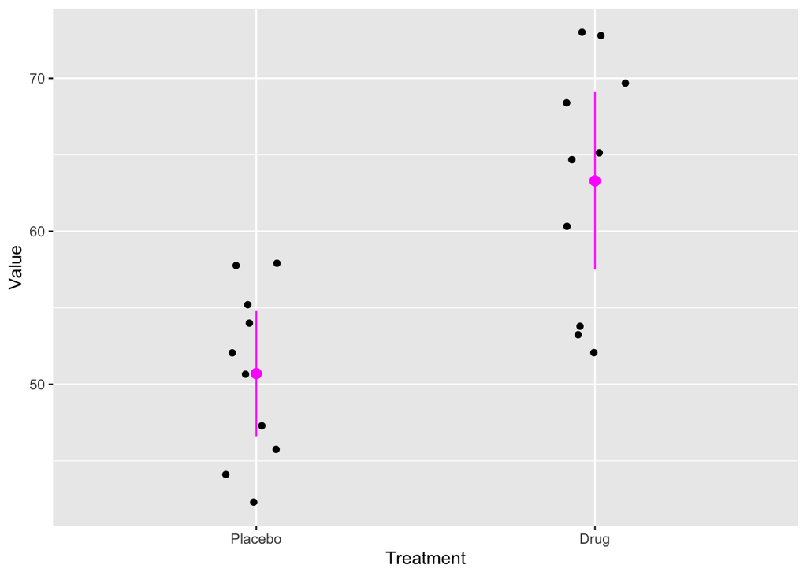

```r
# 95%CI with pointrange (pointrange is default)
p +  stat_summary(fun.data = "mean_cl_normal",
                  geom = "pointrange",
                  col="magenta")
```

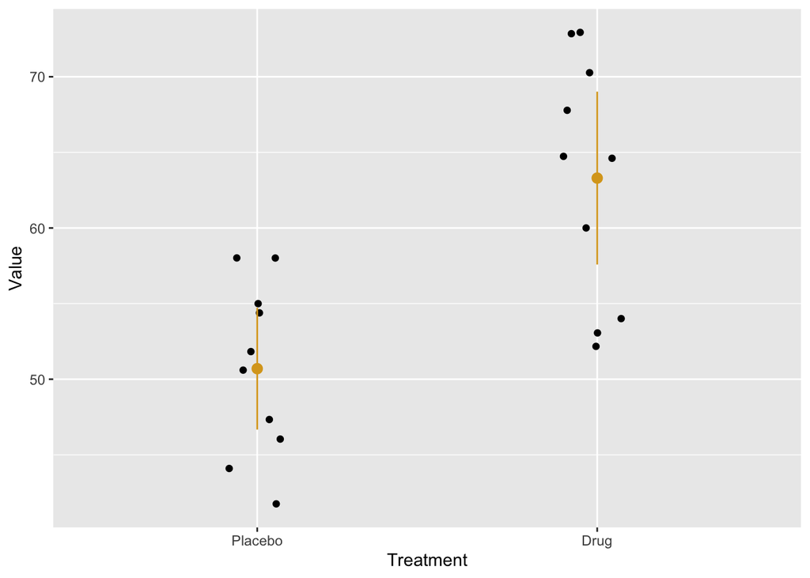

```r
# 95%CI by hand with pointrange (for comparison)
p +  stat_summary(fun = mean,
#               geom = "pointrange",
               fun.max = function(x) mean(x) + qt(.975, df = length(x)) * sd(x) / sqrt(length(x)),
               fun.min = function(x) mean(x) - qt(.975, df = length(x)) * sd(x) / sqrt(length(x)),
               col="goldenrod")
```

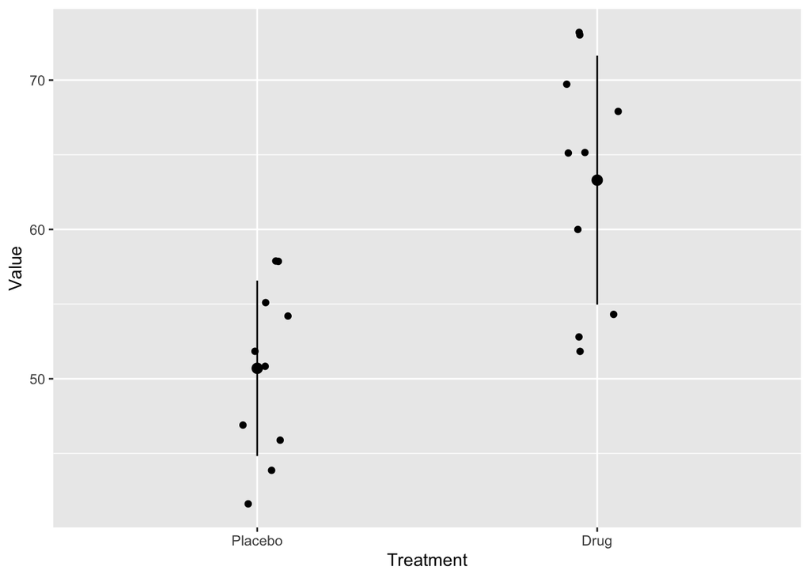

```r
# 99%CI (if you want to change CI limits)
p +  stat_summary(fun.data = "mean_cl_normal",
               fun.args = list( conf.int = .99 )) # 99%CI
```

```r
# ============================================================================ #
# other options

# a) std deviation - note default is 2sd, need multiplier = 1
# p +  stat_summary(fun.data = "mean_sdl",
#                fun.args = list(
#                  mult = 1
#                ),
#                color="red")
#
# # b) std dev with error bars
# p + stat_summary(fun.data = "mean_sdl",
#                geom = "errorbar",
#                width = .05, col="purple",
#                fun.args = list( mult = 1 ))+
#   stat_summary(fun = "mean", geom = "point", col="purple")
#
# # c) std deviation by hand, with point range
# p +  stat_summary(fun = mean,
#                geom = "pointrange",
#                fun.max = function(x) mean(x) + sd(x),
#                fun.min = function(x) mean(x) - sd(x),
#                color="hotpink")

# # c) boxplot with jitterplot overlaid
# ggplot(drug.placebo, aes(x=Treatment, y=Value)) +
#   geom_boxplot() +
#   geom_jitter(position=position_jitter(0.2))
```

Using the rules of thumb given in your textbook, can you conclude by eye from the 95%CI that the samples come from different populations? Why or why not?

```r
# probably very significant b/c CI's do not overlap
```

### Difference in sample means

Another way to frame $H_o$ is to say that we expect the **difference between the two sample means to be 0**. We know this because if we were to plot a distribution of random variables with the same mean, we would expect to get a mean difference of 0. This is the null hypothesis for a two-sample $t$-test.

$$H_o : \mu_{Drug} - \mu_{Placebo} = 0$$
$$H_A : \mu_{Drug} - \mu_{Placebo} \ne 0$$

### The difference in sample means is normally distributed

We already know that the *sampling distribution of the sample mean* is normally distributed, and that the sum or difference of two normally distributed variables is also normally distributed. Therefore, the *difference in sample means must also be normally distributed*.

Now let’s consider the Placebo and Drug samples to be two separate “populations”. If we repeatedly take two random samples from these, we can determine (with 95% confidence) what is the actual difference in the means of the populations.

Let’s check this for ourselves by repeatedly taking two smaller samples from the Placebo and Drug samples and plotting the differenc between them:

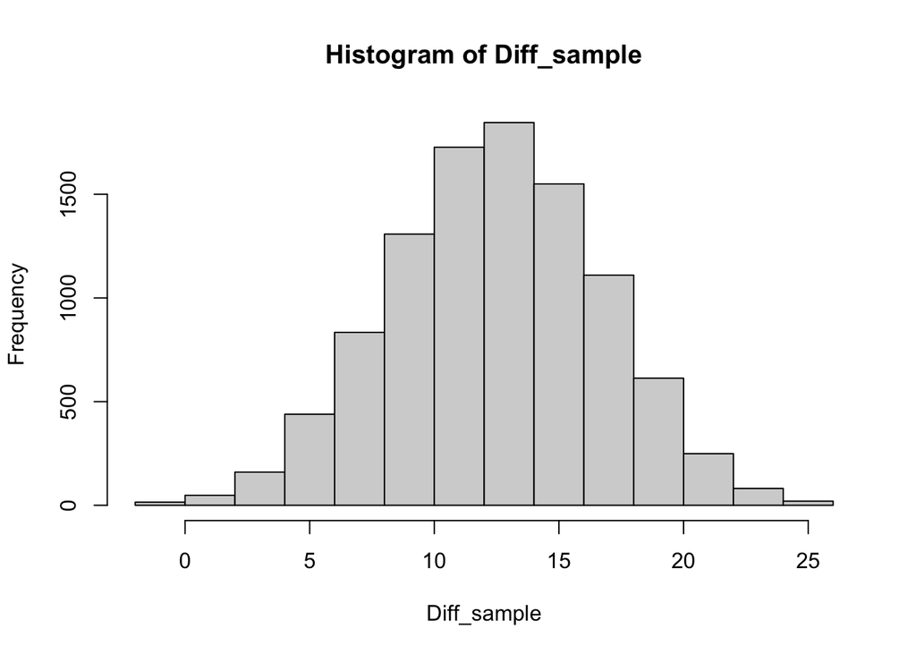

```r
Diff_sample = numeric()
n=5
for (i in 1:10000) {
  Diff_sample[i] = mean(Drug[sample(1:length(Drug), n, replace = T)]) -
                   mean(Placebo[sample(1:length(Placebo),n,replace=T)])
}

hist(Diff_sample)
```

### Standard vs. Welch’s $t$-test

Since we expect that we have random samples drawn from a normal distribution, and our samples are pretty small, it is valid to use $t$-statistics to test our null hypothesis.

The $t$-score for the *observed difference in the means* is computed in the same way as the $z$- or $t$-score for a normal distribution: it is simply the mean difference *standardized* by the standard error:

$$t = \frac{(\bar{Y}_1 - \bar{Y}_2)}{SE_{\bar{Y}_1 - \bar{Y}_2}}$$

For *independent samples*, we have two choices of $t$-test: **Welch’s approximate** $t$-test (for unequal variances) or a standard $t$-test (which assumes equal variances). These differ slightly in the formulas they use for the degrees of freedom and the variance, which is used to compute the standard error.

Below, compare the two variations of the $t$-test.

```r
# perform two versions of a 2-sample test using R
t.test(Drug, Placebo, var.equal = T)  # equal variances
```

```
##
##  Two Sample t-test
##
## data:  Drug and Placebo
## t = 4.0154, df = 18, p-value = 0.0008116
## alternative hypothesis: true difference in means is not equal to 0
## 95 percent confidence interval:
##   6.007433 19.192567
## sample estimates:
## mean of x mean of y
##      63.3      50.7
```

```r
t.test(Drug, Placebo, var.equal = F)  # Welch (unequal variances)
```

```
##
##  Welch Two Sample t-test
##
## data:  Drug and Placebo
## t = 4.0154, df = 16.171, p-value = 0.0009803
## alternative hypothesis: true difference in means is not equal to 0
## 95 percent confidence interval:
##   5.95359 19.24641
## sample estimates:
## mean of x mean of y
##      63.3      50.7
```

How do the results compare?

```r
# The df and consequently the p-value differ slightly for Welch's t-test.
# The confidence interval does not span 0, consistent with the p-value -- both indicate that it is extremely unlikely that the true difference between the Drug and Placebo populations is 0.
```

What is similar and what is different about these results in comparison with the one-sample tests above?

```r
# the means of the two samples and the conclusions from the tests are the same.
# the df and the t-score and p-values are not exactly the same since we are comparing the difference between two samples
```

In practice, it is generally preferred to use Welch’s $t$-test since it has similar power (we will talk about this soon), and it is more robust to differences in variance and sample size.

## Paired $t$-test

What if the data are taken from the *same individuals*? For example, we could test the same patients before and after treatment. In this kind of experimental design, we say that the data are *paired*. If there is no difference between the two measurements for each individual – for example, a new drug for blood pressure has no measurable benefit – then we would expect that our before and after values would be about the same on average.

The **paired $t$-test** is performed in the same way as the one-sample $t$-test, except we use the *mean difference between paired measurements* from the two samples, $\bar{X}_D$, to compute a test statistic. This is a nice design because it controls for inter-individual variation, however it is not appropriate when the two samples are truly independent.

### Null hypothesis

Our *null hypothesis* is usually that the *mean paired difference*, $D_o$, is zero (we could set it to something else if our null hypothesis is that the difference between them is something else …).

For paired data, we *assume that the two sets of measurements are arranged in the same order* as the corresponding individuals (because we have good record-keeping practices!) The test statistic is:

$$t^* = \frac{\bar{X}_{D} - D_0}{\frac{s_{D}}{\sqrt{n}}} = \frac{\bar{X}_{D} - D_0}{SE_{D}} = \frac{\sqrt{n}}{s_D}(\bar{X}_{D} - D_0)$$

where

- $\bar{X_D}$ is the mean of the pairwise differences,
- $s_D$ is the standard deviation of the pairwise differences, and
- $D_0$ is what we are testing (i.e. the expectation for the null hypothesis, which in this case is $0$).

### Test statistic and $p$-value

To compute this $t$-statistic, we can simply subtract one vector from the other to obtain pair-wise differences for each individual, take the mean, and divide by the standard error. We then find the $p$ value in the usual way.

First, find the $t$-statistic and the $p$-value by hand. Then, perform a paired $t$-test for the difference between the two samples.

```r
# paired difference between samples
pair_diff = Drug-Placebo

# t-score and p-value by hand
se_diff = sd(pair_diff)/sqrt(length(pair_diff))
t_stat = mean(pair_diff)/se_diff
t_stat
```

```
## [1] 4.108696
```

```r
2*pt(t_stat, df=9, lower.tail = F)
```

```
## [1] 0.002642154
```

```r
# paired t-test: t.test(treatment, control, ...)
t.test(Drug, Placebo, paired = T, var.equal = T)
```

```
##
##  Paired t-test
##
## data:  Drug and Placebo
## t = 4.1087, df = 9, p-value = 0.002642
## alternative hypothesis: true difference in means is not equal to 0
## 95 percent confidence interval:
##   5.662718 19.537282
## sample estimates:
## mean of the differences
##                    12.6
```

### Relationship between one-sample and paired-sample tests

Study the above equation to convince yourself that the form of the $t$-statistic for a *paired test* is the same as that for a *one-sample* $t$-test, substituting $\bar{X}_D$ for $\bar{X}$, $D_o$ for $\mu_o$, and $s_D$ for $s$.

It is important to note that the result from the **one-sample** $t$-test using the **paired differences** between the two samples gives the same result as a **two-sample** $t$-test with the **paired** option!

Use the `t.test()` function to perform a one-sample test that compares the paired difference vector against the expected mean difference, and then perform a paired $t$-test to verify that the two methods are equivalent.

```r
# one-sample test: sample diff vs. Exp(mu) = 0
t.test(pair_diff, mu=0)
```

```
##
##  One Sample t-test
##
## data:  pair_diff
## t = 4.1087, df = 9, p-value = 0.002642
## alternative hypothesis: true mean is not equal to 0
## 95 percent confidence interval:
##   5.662718 19.537282
## sample estimates:
## mean of x
##      12.6
```

```r
# paired t-test: t.test(treatment, control, ...)
t.test(Drug, Placebo, paired = T, var.equal = T)
```

```
##
##  Paired t-test
##
## data:  Drug and Placebo
## t = 4.1087, df = 9, p-value = 0.002642
## alternative hypothesis: true difference in means is not equal to 0
## 95 percent confidence interval:
##   5.662718 19.537282
## sample estimates:
## mean of the differences
##                    12.6
```

**Note**: when performing any $t$-test with two samples, you must specify the **test set first**, and the **control set second** – otherwise you get a $t$-score that is on the opposite side of the distribution. This will not change your $p$-value, however your **confidence interval** will have the wrong sign!!!